# Executive Summary Report 3

# Shamim Sherafati

### 2022-10-11

## Module 3 - Project

# Abstract

The Report that follows is based on ALY 6000 Module 3. This is authentic work that Miss. Shamim Sherafati completed for the assignment ALY 6000: Introduction to Analytics, and she is submitting it on time, before the decided date and time.

1. Print your name at the top of the script and load these libraries: FSA, FSAdata, magrittr, dplyr, tidyr plyr and tidyverse.

Describe number 1: First, We should loading the libraries and recording our names.

```r
name <- ("Shamim Sherafati")
print(name)
```

```
[1] "Shamim Sherafati"
```

```r
install.packages("FSA")
install.packages("FSAdata")
install.packages("magrittr")
install.packages("plyr")
install.packages("dplyr")
install.packages("tidyr")
install.packages("tidyverse")
```

+1. Call library

```r
library(FSA)
library(FSAdata)
library(magrittr)
library(plyr)
library(dplyr)
library(tidyr)
library(tidyverse)
```

2. Import the inchBio.csv and name the table .

Describe number 2: To begin analysing and processing the data, we should load the dataset in this stage.

```r
bio <- read.table (file="~/Documents/ALY 6000/Module 3/inchBio.csv", header= TRUE, sep=",", stringsAsFactors = FALSE)
bio
```

| netID | fishID | species | tl | w | tag | scale |
| --- | --- | --- | --- | --- | --- | --- |
| 12 | 16 | Bluegill | 61 | 2.9 |  | FALSE |
| 12 | 23 | Bluegill | 66 | 4.5 |  | FALSE |
| 12 | 30 | Bluegill | 70 | 5.2 |  | FALSE |
| 12 | 44 | Bluegill | 38 | 0.5 |  | FALSE |
| 12 | 50 | Bluegill | 42 | 1.0 |  | FALSE |
| 12 | 65 | Bluegill | 54 | 2.1 |  | FALSE |
| 12 | 66 | Bluegill | 27 | NA |  | FALSE |
| 13 | 68 | Bluegill | 36 | 0.5 |  | FALSE |
| 13 | 69 | Bluegill | 59 | 2.0 |  | FALSE |
| 13 | 70 | Bluegill | 39 | 0.5 |  | FALSE |

[output cut: 666 more lines]

3. Display the head, tail and structure of .

Describe number 3: Since it has been requested that we utilise the variable “bio” for the dataset, we will proceed as follows. Additionally, by using the head and tail function, we may examine the dataset’s beginning and last values in the following ways. Also, with structure function, we can find the data.frame values like: netID, fishID, species, tl and etc. and also it gives information about their numbers, too.

```r
head(bio)
```

|  | netID | fishID | species | tl | w | tag | scale |
| --- | --- | --- | --- | --- | --- | --- | --- |
| 1 | 12 | 16 | Bluegill | 61 | 2.9 |  | FALSE |
| 2 | 12 | 23 | Bluegill | 66 | 4.5 |  | FALSE |
| 3 | 12 | 30 | Bluegill | 70 | 5.2 |  | FALSE |
| 4 | 12 | 44 | Bluegill | 38 | 0.5 |  | FALSE |
| 5 | 12 | 50 | Bluegill | 42 | 1.0 |  | FALSE |
| 6 | 12 | 65 | Bluegill | 54 | 2.1 |  | FALSE |

```r
tail(bio)
```

|  | netID | fishID | species | tl | w | tag | scale |
| --- | --- | --- | --- | --- | --- | --- | --- |
| 671 | 121 | 808 | Black Crappie | 323 | 509 | 1050 | TRUE |
| 672 | 121 | 809 | Black Crappie | 282 | 352 | 1700 | TRUE |
| 673 | 121 | 812 | Black Crappie | 142 | 37 |  | TRUE |
| 674 | 110 | 863 | Black Crappie | 307 | 415 | 1783 | TRUE |
| 675 | 129 | 870 | Black Crappie | 279 | 344 | 1789 | TRUE |
| 676 | 129 | 879 | Black Crappie | 302 | 397 | 1792 | TRUE |

```r
str(bio)
```

```
'data.frame':   676 obs. of  7 variables:
 $ netID  : int  12 12 12 12 12 12 12 13 13 13 ...
 $ fishID : int  16 23 30 44 50 65 66 68 69 70 ...
 $ species: chr  "Bluegill" "Bluegill" "Bluegill" "Bluegill" ...
 $ tl     : int  61 66 70 38 42 54 27 36 59 39 ...
 $ w      : num  2.9 4.5 5.2 0.5 1 2.1 NA 0.5 2 0.5 ...
 $ tag    : chr  "" "" "" "" ...
 $ scale  : logi  FALSE FALSE FALSE FALSE FALSE FALSE ...
```

4. Create an object, , that counts and lists all the species records .

Describe number 4 : This demonstrates and confirms that there are 676 values in the Species column, which might be extremely helpful for the analysis.

```r
counts <- c(bio$species)
counts
```

```
  [1] "Bluegill"         "Bluegill"         "Bluegill"         "Bluegill"         "Bluegill"
  [6] "Bluegill"         "Bluegill"         "Bluegill"         "Bluegill"         "Bluegill"
 [11] "Bluegill"         "Bluegill"         "Bluegill"         "Bluegill"         "Bluegill"
 [16] "Bluegill"         "Bluegill"         "Bluegill"         "Bluegill"         "Bluegill"
 [21] "Bluegill"         "Bluegill"         "Bluegill"         "Bluegill"         "Bluegill"
 [26] "Bluegill"         "Bluegill"         "Bluegill"         "Bluegill"         "Bluegill"
 [31] "Bluegill"         "Bluegill"         "Bluegill"         "Bluegill"         "Bluegill"
 [36] "Bluegill"         "Bluegill"         "Bluegill"         "Bluegill"         "Bluegill"
 [41] "Bluegill"         "Bluegill"         "Bluegill"         "Bluegill"         "Bluegill"
 [46] "Bluegill"         "Bluegill"         "Bluegill"         "Bluegill"         "Bluegill"
 [51] "Bluegill"         "Bluegill"         "Bluegill"         "Bluegill"         "Bluegill"
 [56] "Bluegill"         "Bluegill"         "Bluegill"         "Bluegill"         "Bluegill"
 [61] "Bluegill"         "Bluegill"         "Bluegill"         "Bluegill"         "Bluegill"
 [66] "Bluegill"         "Bluegill"         "Bluegill"         "Bluegill"         "Bluegill"
 [71] "Bluegill"         "Bluegill"         "Bluegill"         "Bluegill"         "Bluegill"
```

[output cut: 121 more lines]

5. Display just the 8 levels (names) of the species .

Describe number 5 : The Species column contains 8 different categories, as seen by the code below. Let’s check the unique values in the species column. We can discover that from the following.

```r
Level8th <- unique(bio$species)
Level8th
```

```
[1] "Bluegill"         "Bluntnose Minnow" "Iowa Darter"      "Largemouth Bass"  "Pumpkinseed"      "Tadpole Madtom"
[7] "Yellow Perch"     "Black Crappie"
```

6. Create a object that displays the different species and the number of record of each species in the dataset. Include this information in your report.

Describe number 6 : We can use the table() method to generate results in order to get the count of all the various rows in the 8 distinct types of Species variables. As a result, they are 8 different species with their number of records which can be seen in the following result. For example, Tadpole Madtom with 6 records has the lowest number of score. While, Largemouth Bass and Bluegill have the highest number of records with 228 and 220 respecrively records.

```r
tmp <- table (bio$species)
tmp
```

```
   Black Crappie         Bluegill Bluntnose Minnow      Iowa Darter  Largemouth Bass      Pumpkinseed
              36              220              103               32              228               13
  Tadpole Madtom     Yellow Perch
               6               38
```

7. Create a subset, , of just the species variable and display the first five records .

Describe number 7 : In this stage, I created which will show the the species variable and with using the head function, I show the first five records of dataset.

```r
tmp2 <- subset(bio, select = species)
tmp2
```

|  | species |
| --- | --- |
| 1 | Bluegill |
| 2 | Bluegill |
| 3 | Bluegill |
| 4 | Bluegill |
| 5 | Bluegill |
| 6 | Bluegill |
| 7 | Bluegill |
| 8 | Bluegill |
| 9 | Bluegill |
| 10 | Bluegill |

[output cut: 666 more lines]

```r
head(tmp2, 5)
```

|  | species |
| --- | --- |
| 1 | Bluegill |
| 2 | Bluegill |
| 3 | Bluegill |
| 4 | Bluegill |
| 5 | Bluegill |

8. Create a table, , of the species variable. Display the class of w .

Describe number 8 : Next, I created a table of those species variable and used the class function to be sure that its table.

```r
w <- table (bio$species)
w
```

```
   Black Crappie         Bluegill Bluntnose Minnow      Iowa Darter  Largemouth Bass      Pumpkinseed
              36              220              103               32              228               13
  Tadpole Madtom     Yellow Perch
               6               38
```

```r
class(w)
```

```
[1] "table"
```

9. Convert to a data frame named and display the results .

Describe number 9: After that, I want to know the frequency of the values, and to achieve so, I’ll convert it into a Data Frame and called it .

```r
t <- as.data.frame(w)
t
```

| Var1 | Freq |
| --- | --- |
| Black Crappie | 36 |
| Bluegill | 220 |
| Bluntnose Minnow | 103 |
| Iowa Darter | 32 |
| Largemouth Bass | 228 |
| Pumpkinseed | 13 |
| Tadpole Madtom | 6 |
| Yellow Perch | 38 |

```r
class(t)
```

```
[1] "data.frame"
```

10. Extract and display the frequency values from the data frame .

Describe number 10: In this step, by using t$Freq show the frequency value which I convert it into a Data Frame which called .

```r
t$Freq
```

```
[1]  36 220 103  32 228  13   6  38
```

11. Create a table named from the bio species attribute (variable) and confirm that you created a table which displays the number of species in the dataset .

```r
cSpec <- table(bio$species)
cSpec
```

```
   Black Crappie         Bluegill Bluntnose Minnow      Iowa Darter  Largemouth Bass      Pumpkinseed
              36              220              103               32              228               13
  Tadpole Madtom     Yellow Perch
               6               38
```

```r
class(cSpec)
```

```
[1] "table"
```

12. Create a table named that displays the species and percentage of records for each species. Confirm you created a table class.

Describe number 12: By dividing each species by 676 and multiply 100, we can obtain an estimation and percentage of the species proportion.

```r
cSpecPct <- table(bio$species)/676* 100
cSpecPct
```

```
   Black Crappie         Bluegill Bluntnose Minnow      Iowa Darter  Largemouth Bass      Pumpkinseed
        5.325444        32.544379        15.236686         4.733728        33.727811         1.923077
  Tadpole Madtom     Yellow Perch
        0.887574         5.621302
```

```r
class(cSpecPct)
```

```
[1] "table"
```

13. Convert the table, , to a data frame named and confirm that is a data frame.

Describe number 13: In this dataset, we can use the following way to view and analyze the relative frequencies of the various values.

```r
u <- as.data.frame(cSpecPct)
u
```

| Var1 | Freq |
| --- | --- |
| Black Crappie | 5.325444 |
| Bluegill | 32.544379 |
| Bluntnose Minnow | 15.236686 |
| Iowa Darter | 4.733728 |
| Largemouth Bass | 33.727811 |
| Pumpkinseed | 1.923077 |
| Tadpole Madtom | 0.887574 |
| Yellow Perch | 5.621302 |

```r
class(u)
```

```
[1] "data.frame"
```

14. Create a barplot of with the following: titled Fish Count with the following specifications: • Title: Fish Count • Y axis is labeled “COUNTS” • Color the bars Light Green • Rotate Y axis to be horizontal • Set the X axis font magnification to 60% of nominal

Describe number 14: The Bar Plot above illustrate the fish count of each fish available.The species of the fishare labelled on the X-axis and the count (number) of the fish are labelled on the Y axis, respectively. The Y axis has a range of 0 to 200. This Barplot’s title is “Fish Count.” with Light Green colour which are shown and also, Font magnification has been maintained at 60% of the normal font size. Moreover, the following graph shows that there are more Largemouth bass than any other species of fish. Similarly, Bluegill has the second-highest fish count overall. The number of fish for both largemouth bass and bluegill is over 200. With a combined total of 676 fish and more than 200 fish each, the largemouth bass and bluegill take up around 66% of the whole lot. The average count of the Bluntnose Winnow stands between the species with the greatest and lowest lot. In comparison to largemouth bass and bluegill, the proportions of the species Black Crappie, Iowa darter, Pumpkinseed, Tadpole Madtom, and Yellow Perch are quite low. Compared to all other species, Tadpole Madtom has the fewest fish.

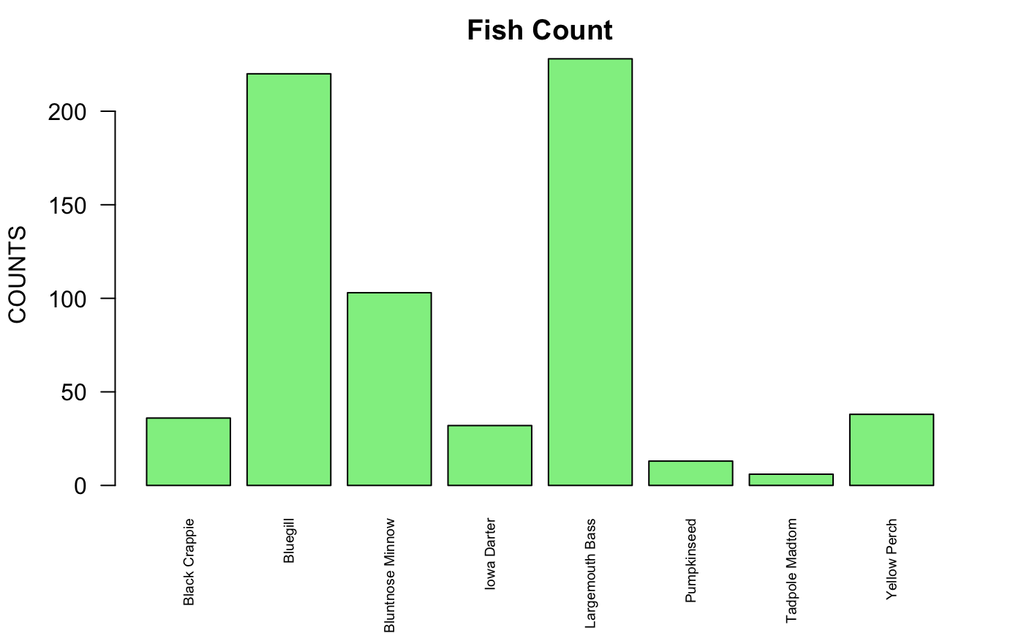

```r
barplot(cSpec, main = "Fish Count",
ylab = "COUNTS",
col = "LightGreen",
las=2,
cex.names = 0.6,
cex.lab=1)
```

15. Create a barplot of , with the following specifications: • Y axis limits of 0 to 4 • Y axis label color of Light Blue • Title of “Fish Relative Frequency”

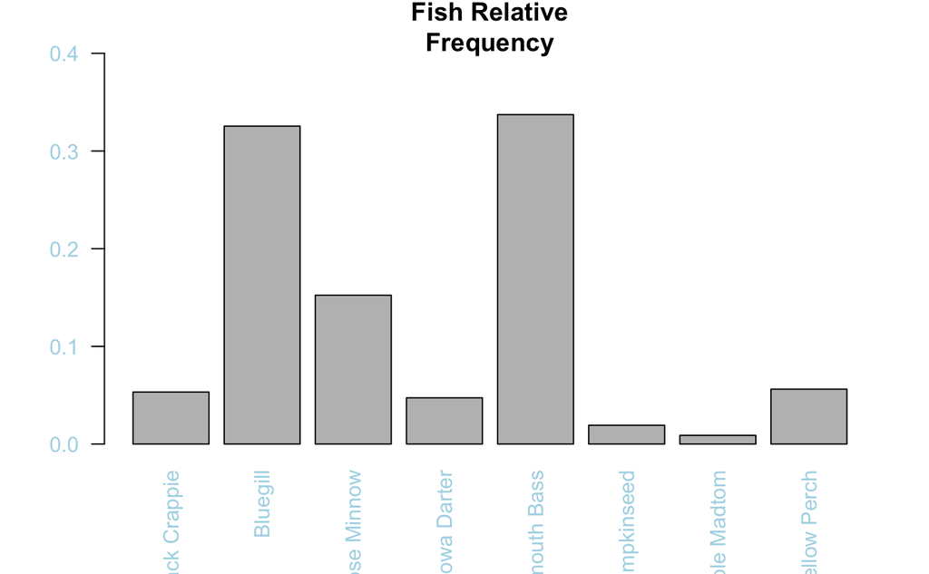

```r
barplot((cSpecPct/100),ylim =c(0,0.4), col.axis = "LightBlue", las=2, main = "Fish Relative
Frequency")
```

16. Rearrange the cSpec Pct data frame in descending order of relative frequency. Save the rearranged data frame as the object .

Describe number 16: The following code can be used to arranging the relative frequency.

```r
d <- u[with(u, order(-Freq)),]
d
```

|  | Var1 | Freq |
| --- | --- | --- |
| 5 | Largemouth Bass | 33.727811 |
| 2 | Bluegill | 32.544379 |
| 3 | Bluntnose Minnow | 15.236686 |
| 8 | Yellow Perch | 5.621302 |
| 1 | Black Crappie | 5.325444 |
| 4 | Iowa Darter | 4.733728 |
| 6 | Pumpkinseed | 1.923077 |
| 7 | Tadpole Madtom | 0.887574 |

17. Rename the columns Var1 to Species, and Freq to RelFreq .

```r
names(d) <- c("Species", "RelFreq")
d
```

|  | Species | RelFreq |
| --- | --- | --- |
| 5 | Largemouth Bass | 33.727811 |
| 2 | Bluegill | 32.544379 |
| 3 | Bluntnose Minnow | 15.236686 |
| 8 | Yellow Perch | 5.621302 |
| 1 | Black Crappie | 5.325444 |
| 4 | Iowa Darter | 4.733728 |
| 6 | Pumpkinseed | 1.923077 |
| 7 | Tadpole Madtom | 0.887574 |

18. Add new variables to and call them cumfreq, counts, and cumcounts.

```r
d <- transform(d, cumfreq = cumsum(RelFreq))
d
```

|  | Species | RelFreq | cumfreq |
| --- | --- | --- | --- |
| 5 | Largemouth Bass | 33.727811 | 33.72781 |
| 2 | Bluegill | 32.544379 | 66.27219 |
| 3 | Bluntnose Minnow | 15.236686 | 81.50888 |
| 8 | Yellow Perch | 5.621302 | 87.13018 |
| 1 | Black Crappie | 5.325444 | 92.45562 |
| 4 | Iowa Darter | 4.733728 | 97.18935 |
| 6 | Pumpkinseed | 1.923077 | 99.11243 |
| 7 | Tadpole Madtom | 0.887574 | 100.00000 |

```r
dcount <- as.data.frame(t[order(-t$Freq),])

d <- transform(d, counts=RelFreq*676)
d
```

|  | Species | RelFreq | cumfreq | counts |
| --- | --- | --- | --- | --- |
| 5 | Largemouth Bass | 33.727811 | 33.72781 | 22800 |
| 2 | Bluegill | 32.544379 | 66.27219 | 22000 |
| 3 | Bluntnose Minnow | 15.236686 | 81.50888 | 10300 |
| 8 | Yellow Perch | 5.621302 | 87.13018 | 3800 |
| 1 | Black Crappie | 5.325444 | 92.45562 | 3600 |
| 4 | Iowa Darter | 4.733728 | 97.18935 | 3200 |
| 6 | Pumpkinseed | 1.923077 | 99.11243 | 1300 |
| 7 | Tadpole Madtom | 0.887574 | 100.00000 | 600 |

```r
d <- transform(d, cumcounts=cumsum(counts))
d
```

|  | Species | RelFreq | cumfreq | counts | cumcounts |
| --- | --- | --- | --- | --- | --- |
| 5 | Largemouth Bass | 33.727811 | 33.72781 | 22800 | 22800 |
| 2 | Bluegill | 32.544379 | 66.27219 | 22000 | 44800 |
| 3 | Bluntnose Minnow | 15.236686 | 81.50888 | 10300 | 55100 |
| 8 | Yellow Perch | 5.621302 | 87.13018 | 3800 | 58900 |
| 1 | Black Crappie | 5.325444 | 92.45562 | 3600 | 62500 |
| 4 | Iowa Darter | 4.733728 | 97.18935 | 3200 | 65700 |
| 6 | Pumpkinseed | 1.923077 | 99.11243 | 1300 | 67000 |
| 7 | Tadpole Madtom | 0.887574 | 100.00000 | 600 | 67600 |

19. Create a parameter variable to store parameter variables .

```r
def_par <- par(mar = c(10,5,5,8))
def_par
```

```
$mar
[1] 5.1 4.1 2.1 2.1
```

20. Create a barplot, , with the following specifications: • d$counts of width 1, spacing of .15 • no boarder • Axes: F • Yaxis limit 0,3.05*max • d$counts na.rm is true • y label is Cummulative Counts • scale x axis to 70% • names.arg: d$Species • Title of the barplot is “Species Pareto” • las: 2)

Describe number 20: The bar chart below shows 8 different species fishes. As can be seen from the chart, the Y-axis shows Cumulative Counts and the X-axis shows these 8 different species fishes which as it is obvious Largemouth Bass and Bluegill experience the significant highest proporotion while, Pumkinseed and Tadpole Madtom has the lowest one.

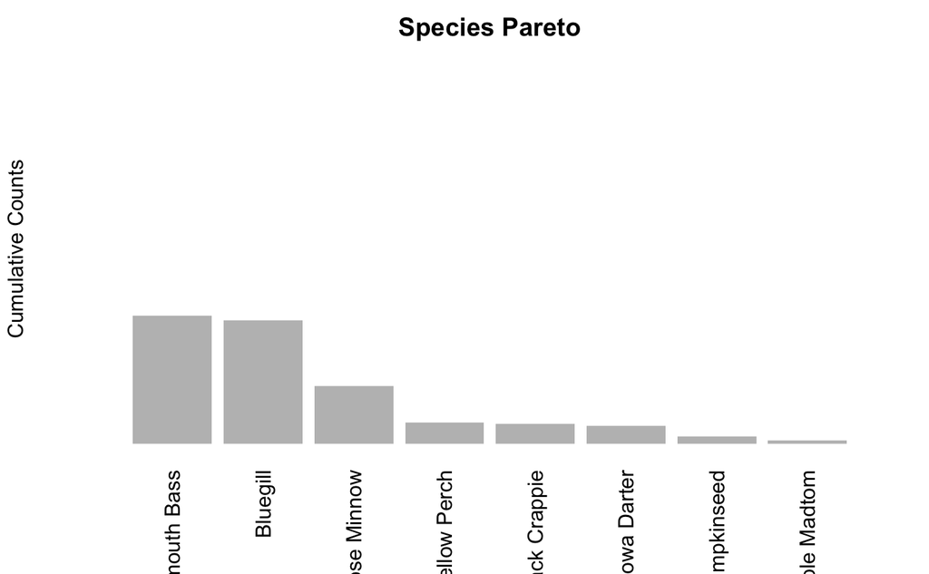

```r
pc <- barplot(d$count, width = 1, space = 0.15, border = NA, axes = F, ylim = c(0, 3.05 * max(d$count, na.rm = TRUE)), ylab = 'Cumulative Counts', cex.axis = 0.7, names.arg = d$Species, main = 'Species Pareto', las = 2)
```

21. Add a cumulative counts line to the plot with the following: • Spec line type is b • Scale plotting text at 70% • Data values are solid circles with color cyan4

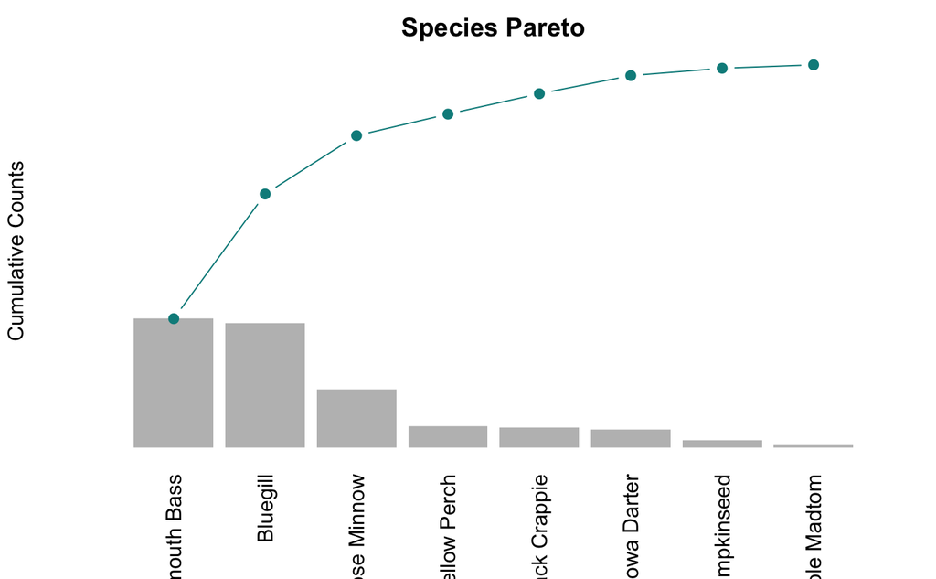

```r
pc <- barplot(d$count, width = 1, space = 0.15, border = NA, axes = F, ylim = c(0, 3.05 * max(d$count, na.rm = TRUE)), ylab = 'Cumulative Counts', cex.axis = 0.7, names.arg = d$Species, main = 'Species Pareto', las = 2)
lines.default (pc, d$cumcounts, type = 'b', pch = 19, col = "cyan4")
```

22. Place a grey box around the pareto plot .

Describe number 22: In this bar plot, just like the previous plot which has the same trend with only difference which we added a box into it.

```r
pc <- barplot(d$count, width = 1, space = 0.15, border = NA, axes = F, ylim = c(0, 3.05 * max(d$count, na.rm = TRUE)), ylab = 'Cumulative Counts', cex.axis = 0.7, names.arg = d$Species, main = 'Species Pareto', las = 2)
lines.default (pc, d$cumcounts, type = 'b', pch = 19, col = "cyan4")
```

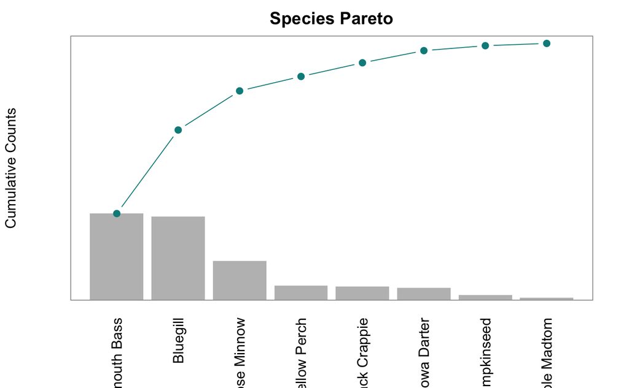

```r
box(col = 'grey62')
```

23. Add a left side axis with the following specifications • Horizontal values at tick marks at cumcounts on side 2 • Tickmark color of grey62 • Color of axis is grey62 • Axis scaled to 80% of normal

Describe number 23: In this question, we continue the previous trend of “pc” bar chart, however we added Horizontal values in left side of the box. So now as can be observed from the chart, we can analyse it more accuraetly; Largemouth Bass which it is 22800 and Bluegill which is approximately 22800 have the highest amount in comare with other type of fishes. But, Tadpole Madtom and Pumkinseed have the lowest amount which are just above 0.

```r
pc <- barplot(d$count, width = 1, space = 0.15, border = NA, axes = F, ylim = c(0, 3.05 * max(d$count, na.rm = TRUE)), ylab = 'Cumulative Counts', cex.axis = 0.7, names.arg = d$Species, main = 'Species Pareto', las = 2)
lines.default (pc, d$cumcounts, type = 'b', pch = 19, col = "cyan4")
```

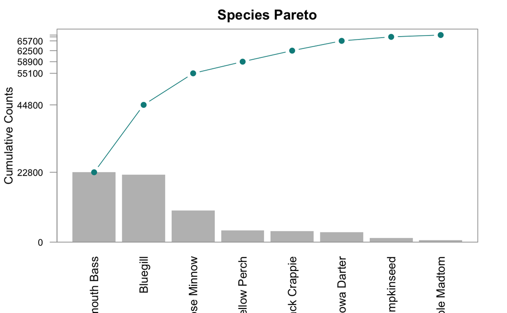

```r
box(col = 'grey62')

axis(side = 2, las = 2, at = c(0, d$cumcounts), tick = TRUE, line = NA, col.ticks = "grey62", col =
"grey62", cex.axis=0.8 )
```

24. Add axis details on right side of box with the specifications: • Spec: Side 4 • Tickmarks at cumcounts with labels from 0 to cumfreq with %, • Axis color of cyan5 and label color of cyan4 • Axis font scaled to 80% of nominal

```r
pc <- barplot(d$count, width = 1, space = 0.15, border = NA, axes = F, ylim = c(0, 3.05 * max(d$count, na.rm = TRUE)), ylab = 'Cumulative Counts', cex.axis = 0.7, names.arg = d$Species, main = 'Species Pareto', las = 2)
lines.default (pc, d$cumcounts, type = 'b', pch = 19, col = "cyan4")
```

```r
box(col = 'grey62')
axis(side = 2, las = 0, at = c(0, d$cumcounts), tick = TRUE, line = NA, col.ticks = "grey62", col =
"grey62")
```

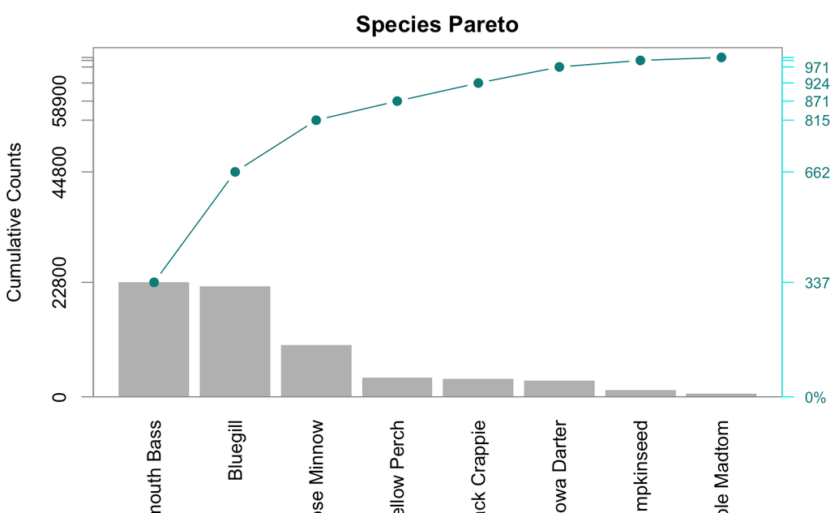

```r
axis(side = 4, at = c(0, d$cumcounts), col = "cyan2", cex.axis = 0.8, las = 2, tick = TRUE,
line = NA, col.axis = "dark cyan", labels = paste0(round( c(0,d$cumfreq) * 100,digits = 0),'%'))
```

25. Display the finished Species Pareto Plot (without the star watermarks). Have your last name on the plot

```r
pc <- barplot(d$count, width = 1, space = 0.15, border = NA, axes = F, ylim = c(0, 3.05 * max(d$count, na.rm = TRUE)), ylab = 'Cumulative Counts', cex.axis = 0.7, names.arg = d$Species, main = 'Sherafati', las = 2)
lines.default (pc, d$cumcounts, type = 'b', pch = 19, col = "cyan4")
```

```r
box(col = 'grey62')
axis(side = 2, las = 2, at = c(0, d$cumcounts), tick = TRUE, line = NA, col.ticks = "grey62", col =
"grey62")
```

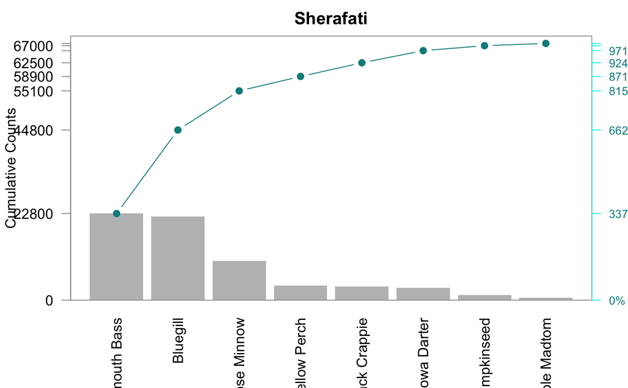

```r
axis(side = 4, at = c(0, d$cumcounts), col = "cyan2", cex.axis = 0.8, las = 2, tick = TRUE,
line = NA, col.axis = "dark cyan", labels = paste0(round( c(0,d$cumfreq) * 100,digits = 0),'%'))
```